# ANÁLISIS ESTADÍSTICO

Alvaro Cesar Tauma Salvador

2022-04-30

# 1 Variables aleatorias

Es una funcion cuyo dominio es un espacio muestral, cuyo rango es un subconjunto de los numeros reales

variable x

aleatoria x

convencionalismo

dom(FUNCIóN o variable aleatoria)= Ω espacio muestral (es el conjunto de resultados posibles de un experimento o de un fenomeno aleatorio)

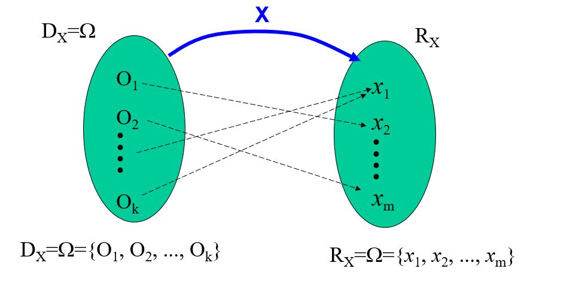

**Ω espacio muestral Son transformados a través de la funcion (variable aleatoria) en numeros**

Ω espacio muestral(texto,numero,caracteres,textocon numero )

A traves de esa transformacion se puede obtener 2 tipos de variable

**Variables continuas**

Son aquellas cuyos rangos forman conjuntos no numerables Ejemplos:

*Cantidad de combustibles consumido por dia* Peso de un producto

# 2 Variables aleatorias discretas

Son aquellas cuyos rangos formas conjuntos numerables pueden contener un numero finito o infinito de elementos

Ejemplo :

*Número de fallas por cada metro de un tejidos.

*Número de articulos defectuosos producidos.

## 2.1 Función de probabilidad o funcion de densidad

**En R dnorm()**

Sea X una variable aleatoria discreta que tiene rango Rx(conjunto de valores que asume la variable aleatoria)

Una función f(x) es llamada funcion de probabilidad de variable aleatoria X si tiene como dominio a Rx(conjunto de valores que asume la variable aleatoria) y como rango un conjunto numero reales que cumplen las siguientes probabilidades.

**Ejemplo:**

Supongamos que tenemos 2 tetraedros y en que en cada una de sus caras estan numeradas del 1 al 4

T1 -> {1,2,3,4}

T2 -> {1,2,3,4}

Experimento E: Se aplica el experimento de lanzar los 2 tetraedros

E:Lanzar 2 tetraedros  
$Ω:{(1,1);(2,1);(3,1);(4,1);(1,2);(2,2),(3,2);(4,2);(1,3);(2,3);(3,3);(4,3);(1,4);(2,4);(3,4);(4,4)}$

```r
T1 <-as.character(c(1:4))
T2 <-as.character(c(1:4))
espacio_muestral <- expand.grid(T1,T2)
espacio_muestral
```

```
##    Var1 Var2
## 1     1    1
## 2     2    1
## 3     3    1
## 4     4    1
## 5     1    2
## 6     2    2
## 7     3    2
## 8     4    2
## 9     1    3
## 10    2    3
## 11    3    3
## 12    4    3
## 13    1    4
## 14    2    4
## 15    3    4
## 16    4    4
```

```r
nrow(espacio_muestral)#cardinal
```

```
## [1] 16
```

**Definimos una variable aleatoria**

X:Diferencia en valor absoluto de los 2 valores que aparecen (variable aleatoria)

X(1,1)=0 P(X(1,1))=1/16

X(2,2)=0 P(X(2,2))=1/16

X(3,3)=0 P(X(3,3))=1/16

X(4,4)=0 P(X(4,4))=1/16

P(X=0)=4/16

X(1,2)=1 P(X(1,2))=1/16

X(2,1)=1 P(X(2,1))=1/16

X(2,3)=1 P(X(2,3))=1/16

X(3,2)=1 P(X(3,2))=1/16

X(3,4)=1 P(X(3,4))=1/16

X(4,3)=1 P(X(4,3))=1/16

P(X=1)=6/16

X(1,3)=2 P(X(1,3))=1/16

X(3,1)=2 P(X(3,1))=1/16

X(2,4)=2 P(X(2,4))=1/16

X(4,2)=2 P(X(4,2))=1/16

P(X=2)=4/16

X(1,4)=3 P(X(1,4))=1/16

X(4,1)=3 P(X(4,1))=1/16

P(X=3)=2/16

**Propiedades Función de probabilidad**

$$0\leq P[X=x_{i}]=f(x_{i}), \forall
x_{i}\in \mathbb R$$

| X | 0 | 1 | 2 | 3 |
| --- | --- | --- | --- | --- |
| P(X=x) | 4/16 | 6/16 | 4/16 | 2/16 |

Dominio $f(x_{i})$ : {0,1,2,3} (conjunto de valores que asume la variable aleatoria)

Rango : { 4/16 ,6/16, 4/16 ,2/16} probabilidad de ocurrencia que tienen variables aleatorias

$$0\leq f(x_{i})\leq 1 ,\forall x_{i}\in
\mathbb R$$

$$\sum_{x_{i}\in \mathbb
R}f(x_{i})=1$$

```r
sum(c(4/16,6/16,4/16,2/16))
```

```
## [1] 1
```

```r
fx <- c(4/16,6/16,4/16,2/16)
X <- c(0,1,2,3)
```

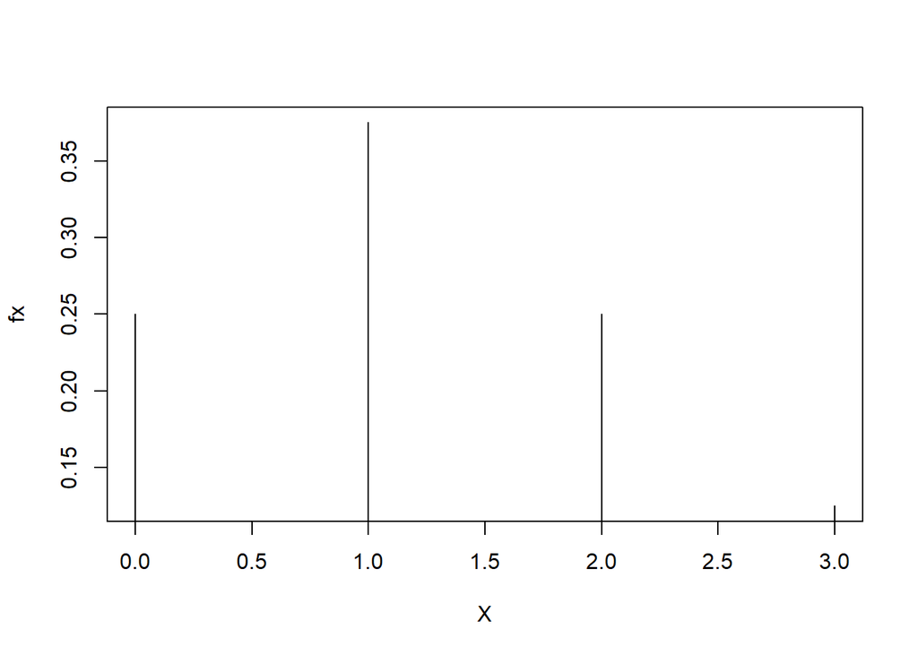

```r
plot(X,fx,type="h")
```

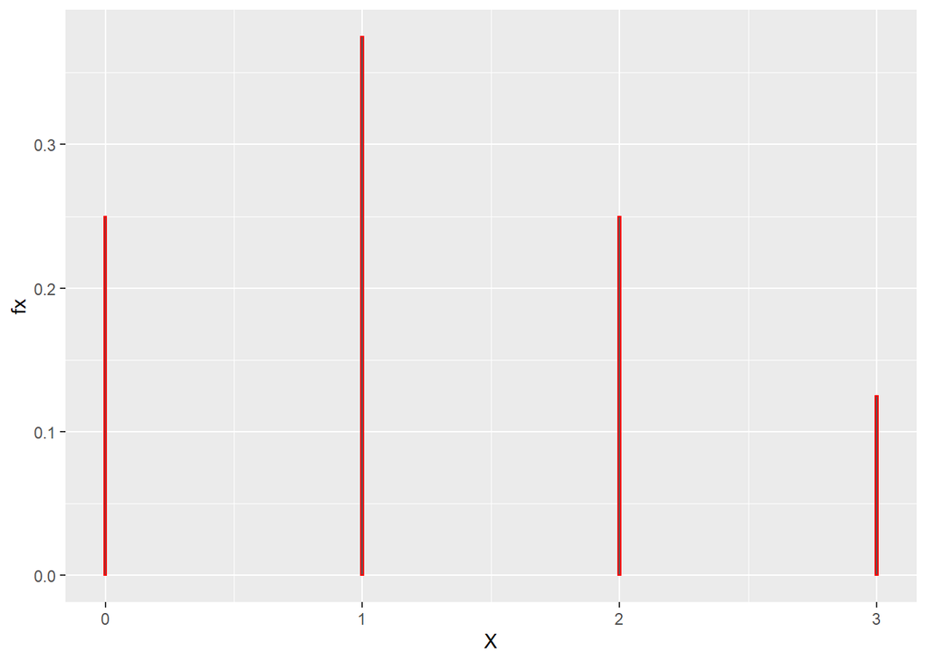

```r
library(ggplot2)
ggplot() + aes(x=X,y=fx) +
  geom_bar(stat="identity",width = 0.01,color="red")
```

SE DEBE PONER UN GRAFICO DE VARAS (se debe colocar la perpendicular en el valor (no una barra))

## 2.2 Funcion probabilidad acumulada FPA

Sea X una variable aleatoria discreta que tiene como funcion probabilidad f(x); luego, la funcion de probabilidad acumulativa de la variable aleatoria X se define como :

$$F(x)=P[X \leq x]=\sum_{x_{i}\leq
x}f(x_{i})$$
**Propiedades**

$$F(x)=0,\forall x< m, m=Min,x\in
R_{x}$$
$$F(x)=1,\forall M\leq x ,
M=Min,x\in R_{x}$$
$$0\leq F(x)\leq 1
,\forall x_{i}\in \mathbb R$$
$F(x)$ es una función no decreciente.

# 3 Variables aleatorias continuas

$$0\leq f(x_{i}), \forall x_{i}\in \mathbb
R$$

dom (valores que puede tomar x)

rango( valores que puede tomar y)

fenomeno: Es una actividad en la cual solo nos limitamos a observar

experimento :Es aquella actividad que ejerces algun tipo de control manejando la variables y la caracteristicas.

dicretos (su recorrido es numerable,se puede contar )

continua :(no se puede contar solo medir no es finito )

# 4 Valor esperado

Valor esperado o esperanza matemática

| X | 2 | 5 |
| --- | --- | --- |
| P(X=x) | 4/5 | 1/5 |

**Función de probabilidad o funcion de densidad**

$$f(x) =
\left\{\begin{array}{lr}4/5 & x=2\\1/5 & x=5 \\ 0 & cc
\\\end{array}\right.$$

**Función de probabilidad acumulada**

$$F(x) =
\left\{\begin{array}{lr}0 & x<2\\4/5 & 2\leq x<5 \\ 1
& 5\leq x \\\end{array}\right.$$

# 5 Distribuciones discreta

Son las funciones de probabilidas asociadas a variables aleatorias discretas,que se generan mediante procesos de conteo sobre las veces que se repite un suceso.

Cuando se elige al azar un elemento, se averigua si cumple o no con cierta condición,para luego contar el número de elemento que si cumplen con la condicion en analisis.

variables aleatorias discretas: cuando su recorrido es finito numeral

## 5.1 Distribucion Bernulli

Un experimento aleatorio es llamado una prueba o ensayo de Bernoulli si cumple las siguientes condiciones:

1.Para cada prueba o ensayo se define un **espacio muestral** con solo **2 resultados posibles**: **Exito(E)** y **Fracaso(F)**.

Donde :

$\pi$=Probabilidad de éxito

X=Número de exitos en una prueba Bernoulli

$$P(E)=\pi$$
$$P(F)=1-P(E)=1-\pi$$
2. La probalidad de exito($\pi$) se mantiene constante de prueba a prueba

3. Las pruebas se consideran que son independientes

(El resultado cada experimento se tiene que realizar en las mismas condiciones)

**Función de probabilidad de una distribucion Bernulli**

$$P(X = x)=f(x) = \left\{\begin{array}{lr}
\pi^x(1 - \pi)^{1-x} & x =0,1\\0
& cc \\\end{array}\right.$$

$$\pi =Exito/Total$$
**1 : Exito**

**0 : Fracaso**

Además, la media y variancia de la variable aleatoria X son :

$$\mu_{X}=E[X]=\pi$$
$$\sigma^2_{X}=E[X^2]-(E[X])^2=\pi-\pi^2=\pi(1-\pi)$$

**Comprobacion utilizando la formula de la valor esperado si X es una variable aleatoria discreta**

- Discreta

| X | 0 | 1 |
| --- | --- | --- |
| f(x)=P(X=x) | 1-π | π |

$$E(X)=\sum x_if_X(x_i)$$
$E(X)=0(1-\pi)+1(\pi)$

$E(X)=\pi$

$\mu_{X}=E(X)$

$\sigma^2_{X}=Var[X]=E[X-\mu_{X}]^2=E[X^2]-\mu_{X}^2=E[X^2]-(E[X])^2 =\pi(1-\pi)$

$E(X^2)=0^2(1-\pi)+1^2(\pi)$

$E(X^2)=\pi$

$\sigma^2_{X}=E[X^2]-(E[X])^2=\pi-\pi^2=\pi(1-\pi)$

## 5.2 Distribucion Binomial

Una variable aleatoria discreta X tiene un distribucion Binomial si su función de probabilidad es dada por

$$P(X = x)=f(x) = \left\{\begin{array}{lr}
\binom nx \pi^x(1 - \pi)^{n-x} & x =0,1..,n\\0
& cc \\\end{array}\right.$$
$$P(X = x)=f(x) = \binom nx \pi^x(1 - \pi)^{n-x}
\quad x =0,1..,n$$

Donde:

$\pi$= Probabilidad de exito

$n$=Número de pruebas de Bernoulli o tamaño de una muestra con reemplazo

X=Numero de exitos en “n” pruebas de Bernoulli

Además,la media y variancia de la variable aleatoria X son :

$$\mu_{X}=E[X]=n\pi$$
$$\sigma^2_{X}=E[X^2]-(E[X])^2=n\pi-n\pi^2=n\pi(1-\pi)$$
**Cuando tienes 2 resultados posibles y el experimento en las mismas condiciones se repite n veces**

### 5.2.1 Combinatoria

Dado un conjunto de N objetos distintos, cualquier subconjunto no ordenado de tamaño n de los objetos se llama combinación y se dentota de las siguiente manera. (no existe reemplazo)

$$\binom nx = \frac{n!}{x!(n-x)!}$$
Ejemplo :

Supongamos que se esta en un micro JUAN,MARIA,ELENA,PEDRO,DAVID,ANA Si se define la variable aleaotoria el número de personas que se contagian.

```r
n <- 6
x <- 2
choose(n, x)
```

```
## [1] 15
```

```r
personas <- c("JUAN","MARIA","ANA","ELENA","PEDRO","DAVID")
```

Todos los arreglos en la que 2 personas se contagian

```r
library(gtools)
combinations(n=6, r=2, v=personas)
```

```
##       [,1]    [,2]
##  [1,] "ANA"   "DAVID"
##  [2,] "ANA"   "ELENA"
##  [3,] "ANA"   "JUAN"
##  [4,] "ANA"   "MARIA"
##  [5,] "ANA"   "PEDRO"
##  [6,] "DAVID" "ELENA"
##  [7,] "DAVID" "JUAN"
##  [8,] "DAVID" "MARIA"
##  [9,] "DAVID" "PEDRO"
## [10,] "ELENA" "JUAN"
## [11,] "ELENA" "MARIA"
## [12,] "ELENA" "PEDRO"
## [13,] "JUAN"  "MARIA"
## [14,] "JUAN"  "PEDRO"
## [15,] "MARIA" "PEDRO"
```

Rpta: Son 15 arreglos de que 2 personas se contagien

Cual es la probabilidad de ANA Y ELENA se contagien

$$\pi=1/15$$

```r
1/choose(6,2)
```

```
## [1] 0.06666667
```

$$P(X = x)=f(x)=\binom
nk\pi^x(1-\pi)^{n-x}$$
$$P(X =
2)=f(2)=\binom 62\pi^2(1-\pi)^{6-2}$$

```r
choose(6,2)*(1/15)^2*(1-(1/15))^(6-2)
```

```
## [1] 0.05058897
```

```r
dbinom(2,6,(1/choose(6,2)))
```

```
## [1] 0.05058897
```

### 5.2.2 Permuntación

Cualquier secuencia ordenada de n objetos tomados de un conjunto de N objetos distintos se llama permutación

$$P_{n}^N=n!\binom
Nn= \frac{N!}{(N-n)!}$$

```r
factorial(5)/factorial(5-2)
```

```
## [1] 20
```

```r
library(gtools)
permutations(6, 2,v=personas,repeats.allowed = F)
```

```
##       [,1]    [,2]
##  [1,] "ANA"   "DAVID"
##  [2,] "ANA"   "ELENA"
##  [3,] "ANA"   "JUAN"
##  [4,] "ANA"   "MARIA"
##  [5,] "ANA"   "PEDRO"
##  [6,] "DAVID" "ANA"
##  [7,] "DAVID" "ELENA"
##  [8,] "DAVID" "JUAN"
##  [9,] "DAVID" "MARIA"
## [10,] "DAVID" "PEDRO"
## [11,] "ELENA" "ANA"
## [12,] "ELENA" "DAVID"
## [13,] "ELENA" "JUAN"
## [14,] "ELENA" "MARIA"
```

[output cut: 16 more lines]

```r
nrow(permutations(6, 2,v=personas,repeats.allowed = F))
```

```
## [1] 30
```

## 5.3 Distribucion Poisson

Una variable aleatoria discreta X tiene una distribución de Poisson si su función de probabilidad es dada por :

$$P(X = x)=f(x) =
\frac{e^{-\mu}\mu^x}{x!} \quad x =0,1,2...\\ 0 , \quad cc$$
Donde:

e= 2718281…cte euler

X=Número de exitos obtenidos en un período o unidad de evaluación.

Ademas,la media y variancia:
$$\mu_{X}=E[X]=\mu$$
$$\sigma^2_{X}=Var[X]=E[X^2]-(E[X])^2=\mu$$
Para la aplicaión de esta distribución es necesario tener en cuenta los siguientes supuestos

1. La tasa promedio de ocurrencia se mantiene constante y es pequeña.
2. El número de ocurrencias en cualquier intervalo ,periodo o unidad de tiempo es independiente del número de ocurrencias en cualquier otro intervalo,periodo o unidad de evaluación.

## 5.4 Distribucion Hipergeometrica

Sea una población de tamaño N, donde hay A elementos que tienen una carateristica W definida como exito,y B elementos que no tienen caracteristica W,siendo N=A+B.Si de dicha poblacion se toma una muestra aleatoria X tendra una muestra aleatoria de tamaño n y se define la variable aleatoria x czomo el número de éxitos obtenidos;entonces la variable X tendra como función de probabilidad.

$$f(x)= \frac{\binom Ax\binom
B{N-x}}{\binom Nn},si\quad x=0,1,2,..,n \\ \text{(0,lo peor que puede
suceder )}\leq x\leq \text{(lo mas optimo que puede suceder o n,A)}\\ 0
,\quad cc$$

$$f(x)= \frac{\binom Ax\binom
B{N-x}}{\binom Nn},si\quad x=0,1,2,..,n \\ max(0,n+A-N)\leq x \leq
min(n,A)$$

N:Tamaño de poblacion

n:Tamaño de muestra

x:Numero de exitos obtenidos en una muestra sin reemplazo de tamaño n (**x no siempre arranca de 0**)

Ademas,la media y varianza de la variable aleatoria X son

$$\mu_{X}=E[X]=\frac{nA}{N}$$

$$\sigma^2_{X}=Var[X]=\frac{nAB}{N^2}[\frac{N-n}{N-1}]$$

# 6 Distribución continuas

Son las funciones de probabilidad asociadas a variables aleatorias continuas; es decir; para aquellas variables cuyo rango es un conjunto infinito no numerable.

En una distribucion continua la funcion de densidad no representa probabilidad **(no existe probabilidad puntual)**

## 6.1 Distribucion normal

$$f(x)=\frac{1}{\sqrt{2\pi}\sigma}
e^{-\frac{1}{2}(\frac{x-\mu}{\sigma})^2} \qquad \text{para todo x
real}$$
$\pi=3.1416$

Donde:

$$\mu_{X}=E[X]=\mu$$
$$\sigma^2_{X}=Var[X]=\sigma^2$$